# HW 4

Philip Warton 933328296

## Problem 1

### A

```r
head(ex1123)
```

```
##              City   Mort Precip Educ NonWhite NOX SO2
## 1    San Jose, CA 790.73     13 12.2      3.0  32   3
## 2     Wichita, KS 823.76     28 12.1      7.5   2   1
## 3   San Diego, CA 839.71     10 12.1      5.9  66  20
## 4   Lancaster, PA 844.05     43  9.5      2.9   7  32
## 5 Minneapolis, MN 857.62     25 12.1      2.0  11  26
## 6      Dallas, TX 860.10     35 11.8     14.8   1   1
```

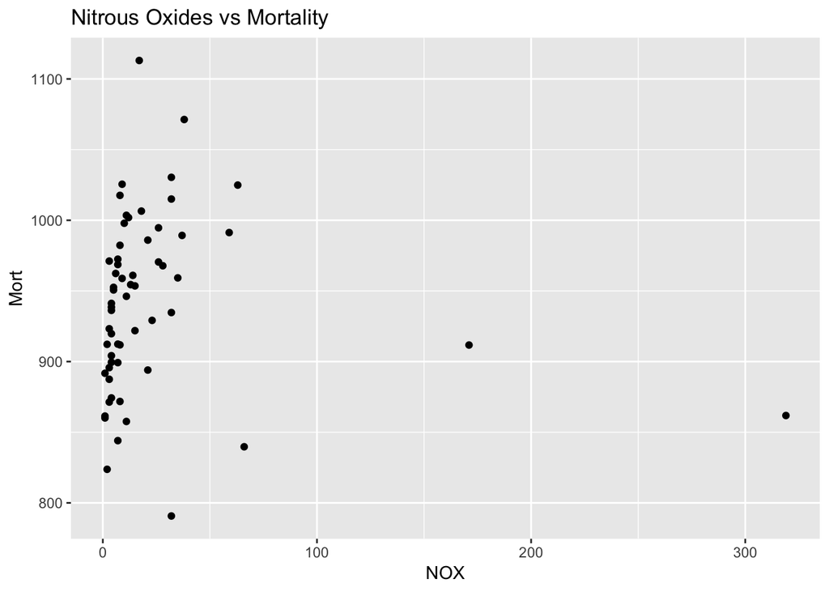

```r
ggplot(ex1123, aes(NOX, Mort)) +
  geom_point() +
  ggtitle("Nitrous Oxides vs Mortality")
```

Looking at this scatterplot it does not appear that there is a linear relationship, and there are several possible outliers, these being cities with extremely high amounts of nitrous oxides.

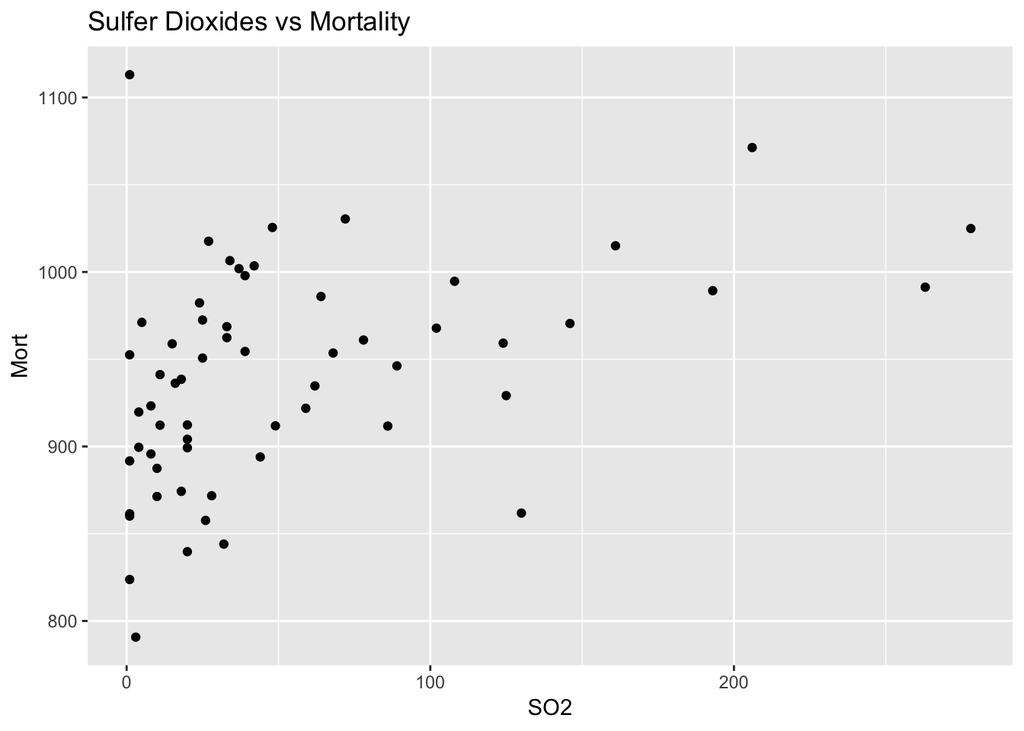

```r
ggplot(ex1123, aes(SO2, Mort)) +
  geom_point() +
  ggtitle("Sulfer Dioxides vs Mortality")
```

Looking at this scatter plot it looks like a linear relation might be plausible, and the value in the top left with an extremely high mortality rate with almost no sulfer dioxides might be an outlier.

### B

```r
modelB <- lm(data=ex1123, Mort ~ Precip + Educ + NonWhite + SO2)
summary(modelB)
```

```
##
## Call:
## lm(formula = Mort ~ Precip + Educ + NonWhite + SO2, data = ex1123)
##
## Residuals:
##     Min      1Q  Median      3Q     Max
## -94.799 -20.580  -2.503  17.433  92.208
##
## Coefficients:
##              Estimate Std. Error t value Pr(>|t|)
## (Intercept) 999.31666   92.07879  10.853 2.74e-15 ***
## Precip        1.61114    0.63358   2.543 0.013836 *
## Educ        -15.77352    6.99213  -2.256 0.028074 *
## NonWhite      3.06091    0.61401   4.985 6.53e-06 ***
## SO2           0.32719    0.08387   3.901 0.000263 ***
## ---
## Signif. codes:  0 '***' 0.001 '**' 0.01 '*' 0.05 '.' 0.1 ' ' 1
##
## Residual standard error: 37.24 on 55 degrees of freedom
## Multiple R-squared:  0.6659, Adjusted R-squared:  0.6416
## F-statistic: 27.41 on 4 and 55 DF,  p-value: 1.554e-12
```

```r
modelBnox <- lm(data=ex1123, Mort ~ Precip + Educ + NonWhite + NOX + SO2)
summary(modelBnox)
```

```
##
## Call:
## lm(formula = Mort ~ Precip + Educ + NonWhite + NOX + SO2, data = ex1123)
##
## Residuals:
##     Min      1Q  Median      3Q     Max
## -91.893 -18.986  -3.433  15.872  91.528
##
## Coefficients:
##              Estimate Std. Error t value Pr(>|t|)
## (Intercept) 1000.1026    92.3982  10.824 3.85e-15 ***
## Precip         1.3792     0.7000   1.970 0.053943 .
## Educ         -15.0791     7.0706  -2.133 0.037518 *
## NonWhite       3.1602     0.6287   5.026 5.84e-06 ***
## NOX           -0.1076     0.1359  -0.792 0.432030
## SO2            0.3554     0.0914   3.889 0.000278 ***
## ---
## Signif. codes:  0 '***' 0.001 '**' 0.01 '*' 0.05 '.' 0.1 ' ' 1
##
## Residual standard error: 37.36 on 54 degrees of freedom
## Multiple R-squared:  0.6698, Adjusted R-squared:  0.6392
## F-statistic:  21.9 on 5 and 54 DF,  p-value: 6.478e-12
```

### C

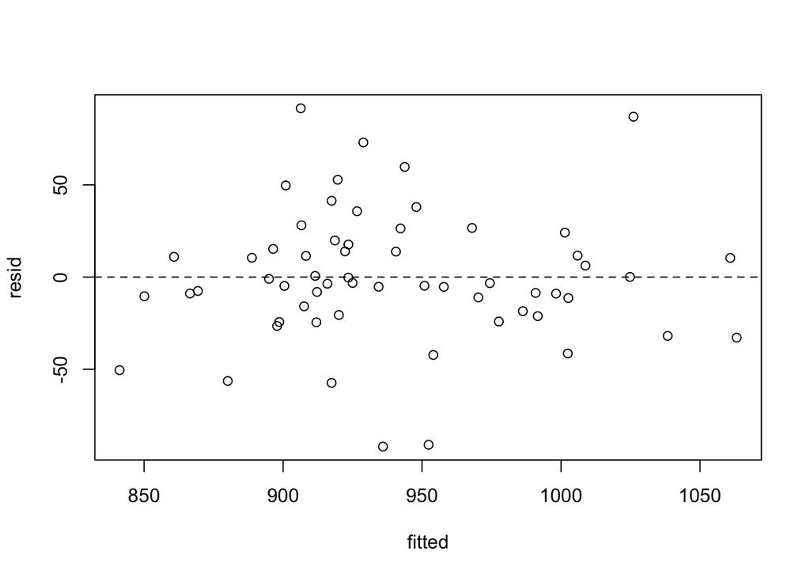

```r
modelC <- modelBnox
resid <- residuals(modelC)
fitted <- fitted(modelC)
plot(fitted,resid);abline(0,0,lty=2)
```

The residual plot appears good, it would seem as though there is a constant variance, and a somewhat normal distribution throughout.

### D

```r
modelD <- lm(data=ex1123, Mort ~ Precip + Educ + NonWhite + log(NOX) + log(SO2))
summary(modelD)
```

```
##
## Call:
## lm(formula = Mort ~ Precip + Educ + NonWhite + log(NOX) + log(SO2),
##     data = ex1123)
##
## Residuals:
##      Min       1Q   Median       3Q      Max
## -102.222  -19.547    0.239   20.084   95.386
##
## Coefficients:
##             Estimate Std. Error t value Pr(>|t|)
## (Intercept) 940.6584    94.0551  10.001 6.81e-14 ***
## Precip        1.9467     0.7007   2.778   0.0075 **
## Educ        -14.6645     6.9379  -2.114   0.0392 *
## NonWhite      3.0289     0.6685   4.531 3.29e-05 ***
## log(NOX)      6.7164     7.3990   0.908   0.3680
## log(SO2)     11.3578     5.2955   2.145   0.0365 *
## ---
## Signif. codes:  0 '***' 0.001 '**' 0.01 '*' 0.05 '.' 0.1 ' ' 1
##
## Residual standard error: 36.3 on 54 degrees of freedom
## Multiple R-squared:  0.6883, Adjusted R-squared:  0.6594
## F-statistic: 23.85 on 5 and 54 DF,  p-value: 1.418e-12
```

```r
anova(modelD, modelC, test="F")
```

```
## Analysis of Variance Table
##
## Model 1: Mort ~ Precip + Educ + NonWhite + log(NOX) + log(SO2)
## Model 2: Mort ~ Precip + Educ + NonWhite + NOX + SO2
##   Res.Df   RSS Df Sum of Sq F Pr(>F)
## 1     54 71159
## 2     54 75385  0     -4226
```

### E

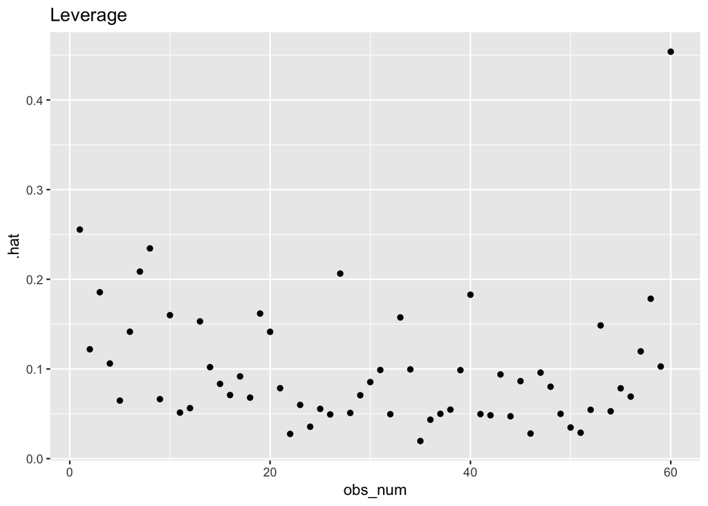

```r
modelE <- modelD

data <- fortify(modelE, ex1123)
data$obs_num <- 1:nrow(data)
qplot(obs_num, .hat, data  = data) + ggtitle("Leverage")
```

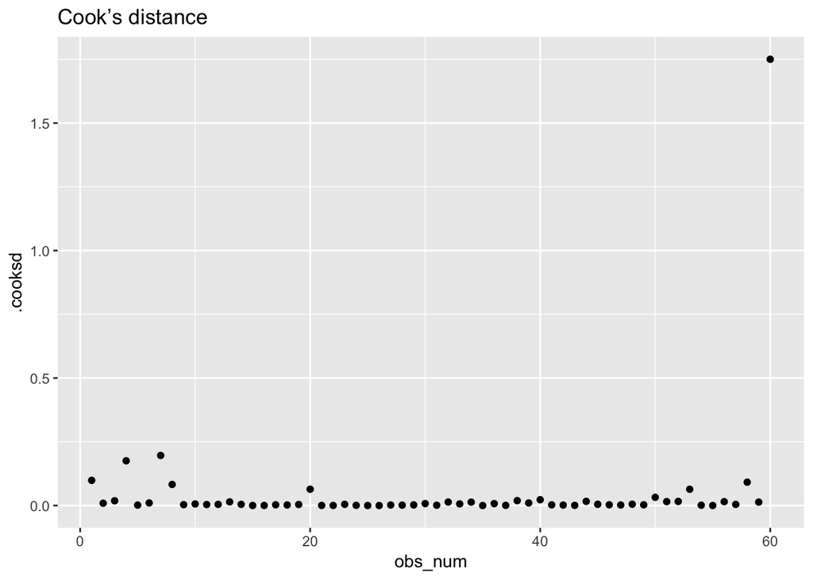

```r
qplot(obs_num, .cooksd, data  = data)  + ggtitle("Cook’s distance")
```

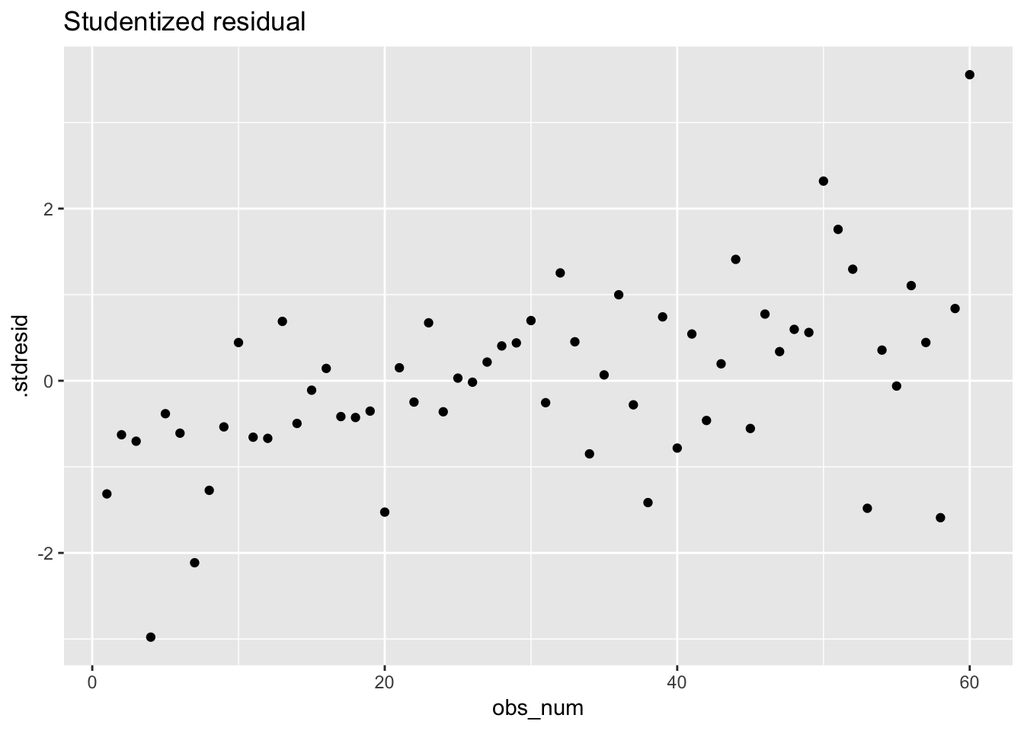

```r
qplot(obs_num, .stdresid, data  = data)  + ggtitle("Studentized residual")
```

Observation number 60 does appear to be very influential, especially when compared to the other points.

### F

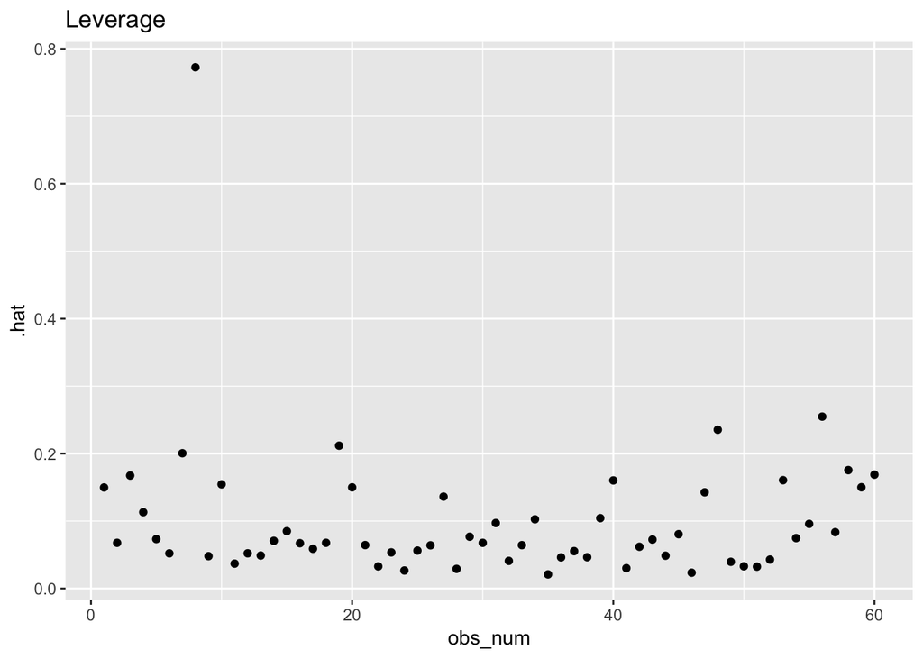

```r
modelF <- lm(data=ex1123, Mort ~ Precip + Educ + NonWhite + NOX + SO2)
data <- fortify(modelF, ex1123)
data$obs_num <- 1:nrow(data)
qplot(obs_num, .hat, data  = data) + ggtitle("Leverage")
```

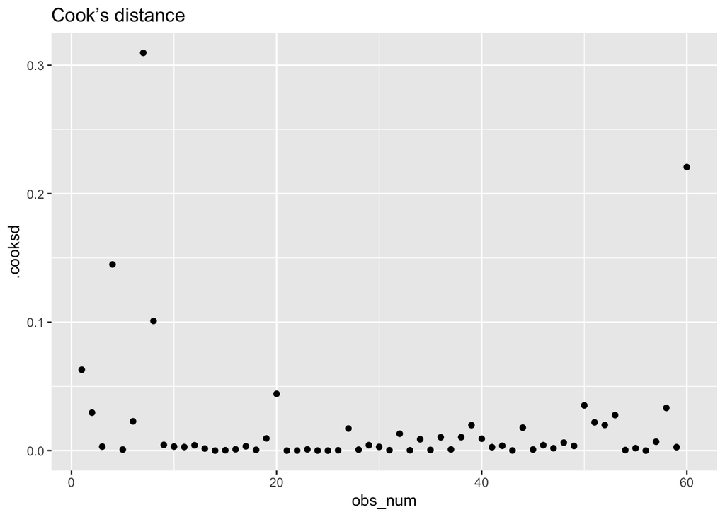

```r
qplot(obs_num, .cooksd, data  = data)  + ggtitle("Cook’s distance")
```

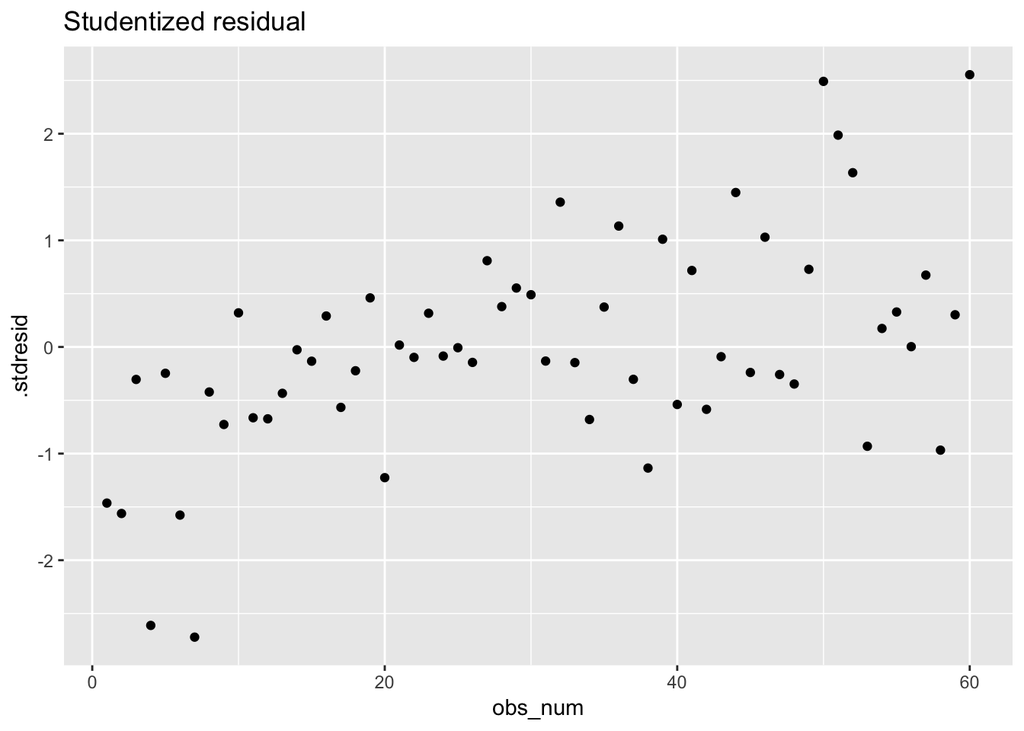

```r
qplot(obs_num, .stdresid, data  = data)  + ggtitle("Studentized residual")
```

```r
data2 <- data[-c(8,60),]
modelF2 <- lm(data=data2, Mort ~ Precip + Educ + NonWhite + NOX + SO2)
summary(modelF2)
```

```
##
## Call:
## lm(formula = Mort ~ Precip + Educ + NonWhite + NOX + SO2, data = data2)
##
## Residuals:
##     Min      1Q  Median      3Q     Max
## -88.098 -17.468  -2.986  20.553  90.014
##
## Coefficients:
##              Estimate Std. Error t value Pr(>|t|)
## (Intercept) 967.78045   89.22863  10.846 5.84e-15 ***
## Precip        1.32668    0.68350   1.941  0.05769 .
## Educ        -11.87022    6.92803  -1.713  0.09260 .
## NonWhite      2.74898    0.62734   4.382 5.73e-05 ***
## NOX          -0.11033    0.25278  -0.436  0.66430
## SO2           0.40273    0.09795   4.111  0.00014 ***
## ---
## Signif. codes:  0 '***' 0.001 '**' 0.01 '*' 0.05 '.' 0.1 ' ' 1
##
## Residual standard error: 35.69 on 52 degrees of freedom
## Multiple R-squared:  0.6553, Adjusted R-squared:  0.6222
## F-statistic: 19.77 on 5 and 52 DF,  p-value: 5.497e-11
```

Many of the estimates have decreased somewhat, and the coefficient for education no longer appears significant with a significance level of $\alpha = 0.05$.

### G

```r
modelG <- modelF2
partialResid <- residuals(modelG, type="partial")
colnames(partialResid) <- paste("resid", colnames(partialResid), sep = "")
dataResid <- cbind(data2, partialResid)
head(dataResid)
```

```
##              City   Mort Precip Educ NonWhite NOX SO2       .hat   .sigma
## 1    San Jose, CA 790.73     13 12.2      3.0  32   3 0.14980978 36.95799
## 2     Wichita, KS 823.76     28 12.1      7.5   2   1 0.06772042 36.85250
## 3   San Diego, CA 839.71     10 12.1      5.9  66  20 0.16745602 37.68180
## 4   Lancaster, PA 844.05     43  9.5      2.9   7  32 0.11309232 35.25223
## 5 Minneapolis, MN 857.62     25 12.1      2.0  11  26 0.07324656 37.69289
## 6      Dallas, TX 860.10     35 11.8     14.8   1   1 0.05211699 36.83567
##        .cooksd  .fitted     .resid  .stdresid obs_num residPrecip
## 1 0.0629589954 841.1725 -50.442494 -1.4641733       1   -87.95458
## 2 0.0295330686 880.1059 -56.345894 -1.5618639       2   -70.98650
## 3 0.0031089119 850.0920 -10.382038 -0.3045321       3   -51.22872
## 4 0.1449416669 935.9425 -91.892507 -2.6115292       4   -80.84658
## 5 0.0008036355 866.5043  -8.884271 -0.2469981       5   -31.08226
## 6 0.0227858205 917.4613 -57.361307 -1.5768692       6   -58.38547
##   residEduc residNonWhite  residNOX  residSO2
## 1 -69.93596     -79.05590 -56.98976 -75.68727
## 2 -71.68106     -69.61760 -56.61195 -79.42484
## 3 -28.04304     -30.37796 -20.03513 -28.13504
## 4 -70.57877    -112.02320 -86.92388 -96.70062
## 5 -27.79678     -40.85272 -13.72065 -25.47242
## 6 -64.80572     -46.23576 -53.18734 -76.11056
```

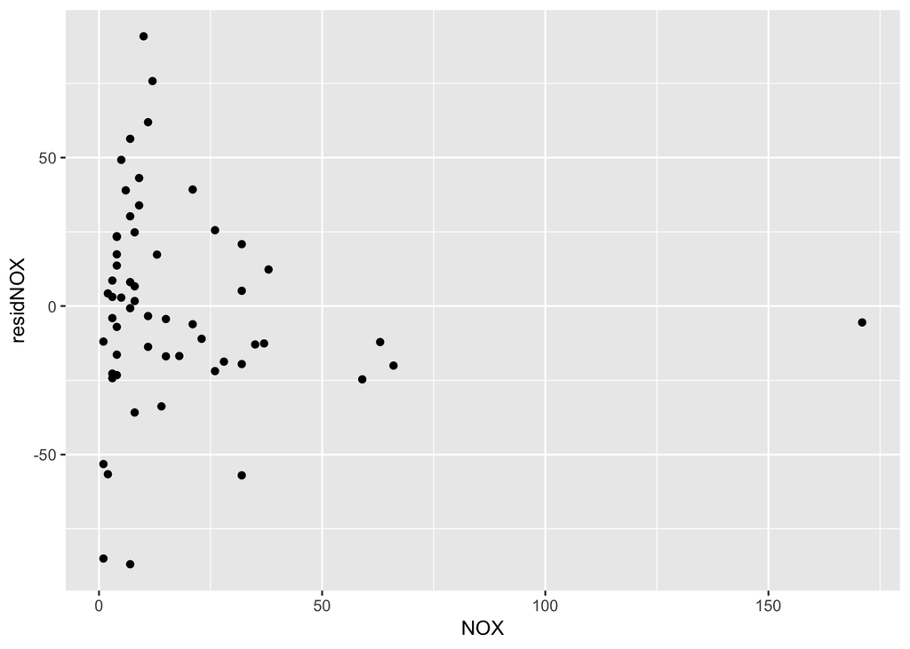

```r
qplot(NOX, residNOX, data = dataResid)
```

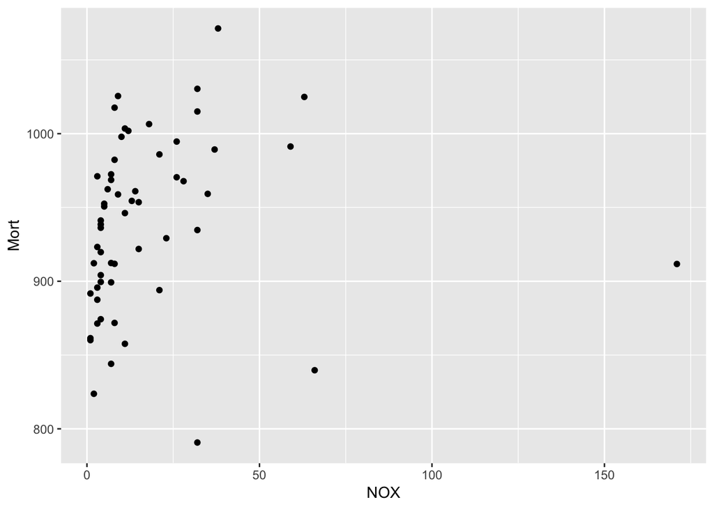

```r
qplot(NOX, Mort, data = dataResid)
```

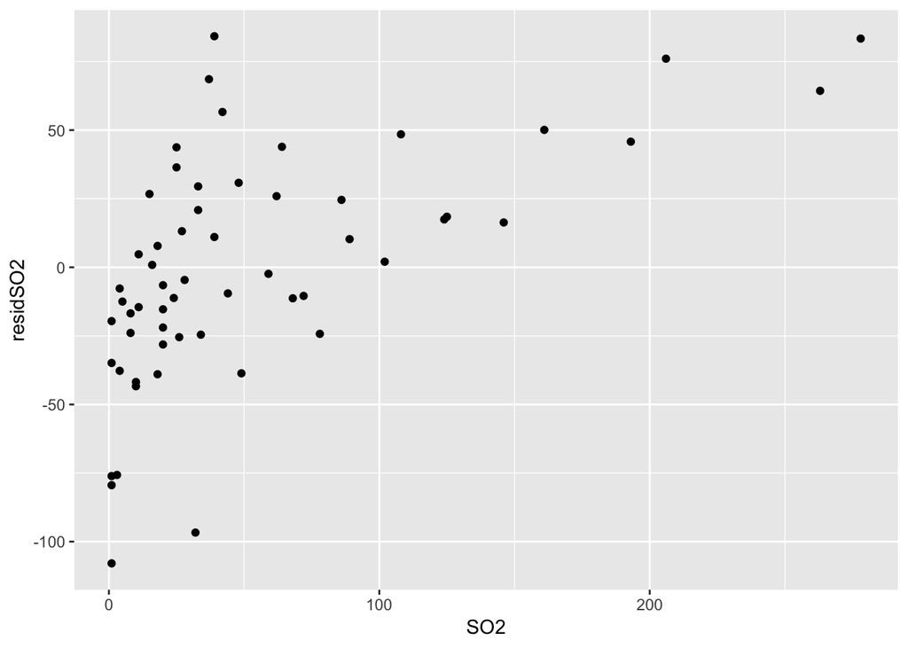

```r
qplot(SO2, residSO2, data = dataResid)
```

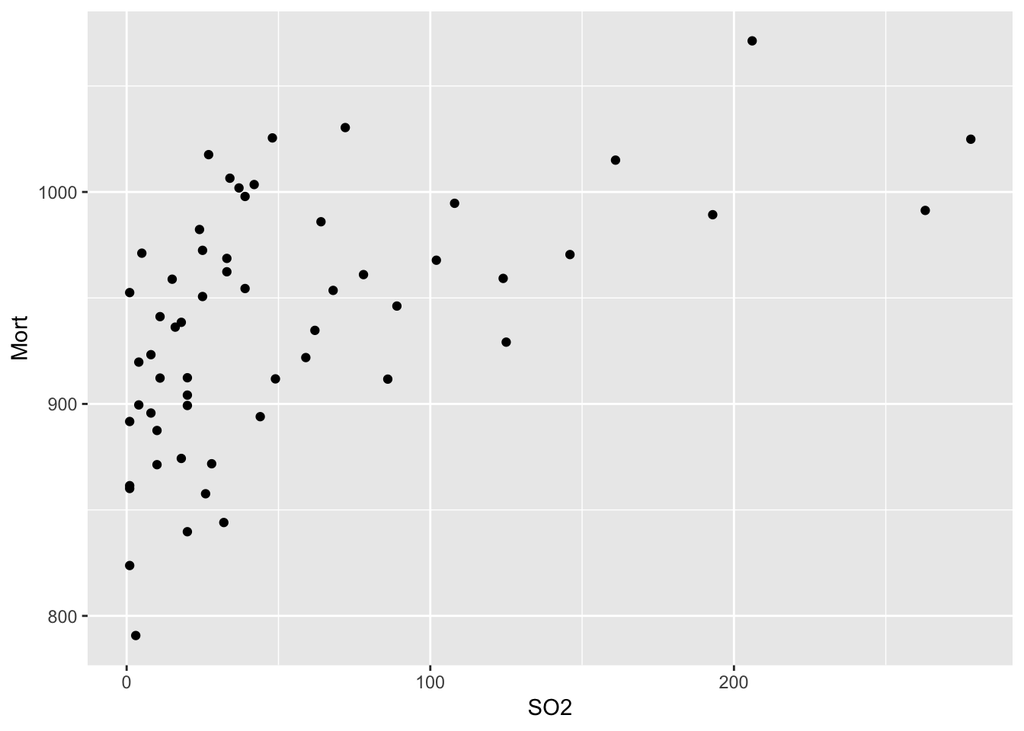

```r
qplot(SO2, Mort, data = dataResid)
```

Since the relationship between response (Mortality) and explanatory (Nitrous Oxide) variable does not change significantly from the scatterplot to the partial residual plot, so we can say that the relationship between response and explanatory variable is not significantly affected by the other explanatory variables. The same is true for the (Sulfur Dioxide) explanatory variable.

### H

There does not appear to be a relationship between the (NOX) explanatory variable and the response (Mortality). When accounting for the effect of other explanatory variables the relationship does not significantly change.

There does appear to be a relationship between the (SO2) explanatory variable and the response (Mortality). When accounting for the effect of other explanatory variables the relationship does not significantly change.